# RepData_PeerAssessment1

Than Win

Friday, April 10, 2015

## Loading and preprocessing the data

1. Load the data

```r
activity <- read.csv(unz("activity.zip", "activity.csv"))
```

2. Process/transform the data (if necessary) into a format suitable for the analysis

```r
activity$date <- as.Date(activity$date, "%Y-%m-%d")
```

## What is mean total number of steps taken per day?

1.Calculate the total number of steps taken per day

```r
library(dplyr)
total_spd <- group_by(activity, date) %>% summarize(steps = sum(steps, na.rm = TRUE)) %>% filter(steps != 0)
mean_total_spd <- mean(total_spd$steps)
median_total_spd <- median(total_spd$steps)
```

2. Histogram of the total number of steps taken each day

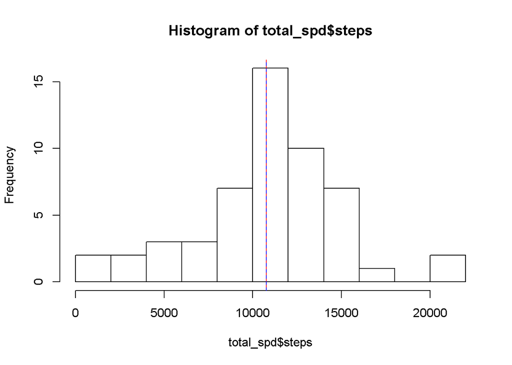

```r
hist(total_spd$steps, breaks=10)
abline(v=mean_total_spd, col = c("red"))
abline(v=median_total_spd, col = c("blue"), lty = 2)
```

3. Calculate and report the mean and median of the total number of steps taken per day

```r
mean_total_spd <- mean(total_spd$steps)
mean_total_spd
```

```
## [1] 10766.19
```

```r
median_total_spd <- median(total_spd$steps)
median_total_spd
```

```
## [1] 10765
```

## What is the average daily activity pattern?

1. a time series plot (i.e. type = “l”) of the 5-minute interval (x-axis) and the average number of steps taken, averaged across all days (y-axis)

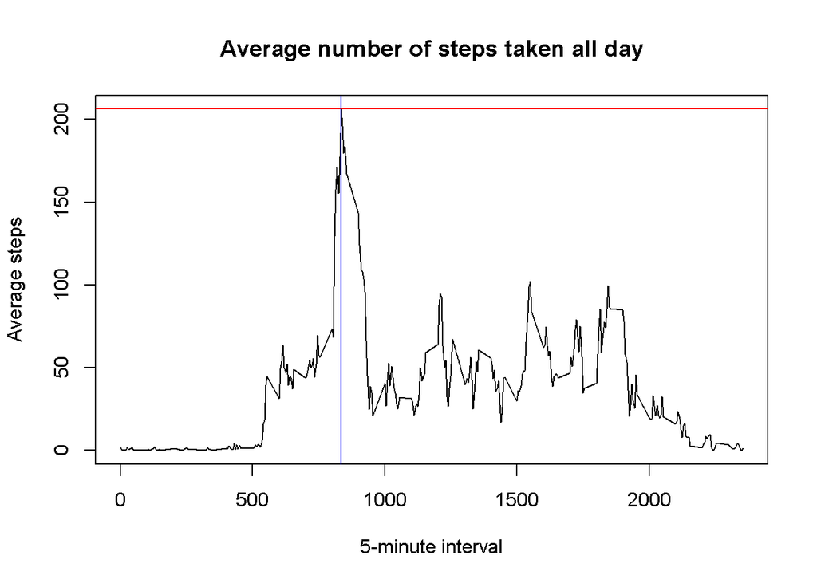

```r
average_spi <- group_by(activity, interval) %>% summarize(steps = mean(steps, na.rm = TRUE)) %>% filter(steps != 0)
max_average_spi <- filter(average_spi, steps == max(steps))

with(average_spi,
     plot(interval, steps, type='l'
          , main="Average number of steps taken all day"
          , xlab="5-minute interval"
          , ylab="Average steps")
     )
abline(h=max_average_spi$steps, col = c("red"))
abline(v=max_average_spi$interval, col = c("blue"))
```

2. Which 5-minute interval, on average across all the days in the dataset, contains the maximum number of steps?

```r
max_average_spi <- filter(average_spi, steps == max(steps))
max_average_spi
```

```
## Source: local data frame [1 x 2]
##
##   interval    steps
## 1      835 206.1698
```

## Imputing missing values

1. Calculate and report the total number of missing values in the dataset (i.e. the total number of rows with NAs)

```r
index <- which(is.na(activity$steps))
length(index)
```

```
## [1] 2304
```

2/3. Devise a strategy for filling in all of the missing values in the dataset. Create a new dataset that is equal to the original dataset but with the missing data filled in.

```r
new_activity <- activity
new_activity[index, 1] <- average_spi[as.factor(activity[index, 3]), 2]
```

4. A histogram of the total number of steps taken each day and Calculate and report the mean and median total number of steps taken per day.

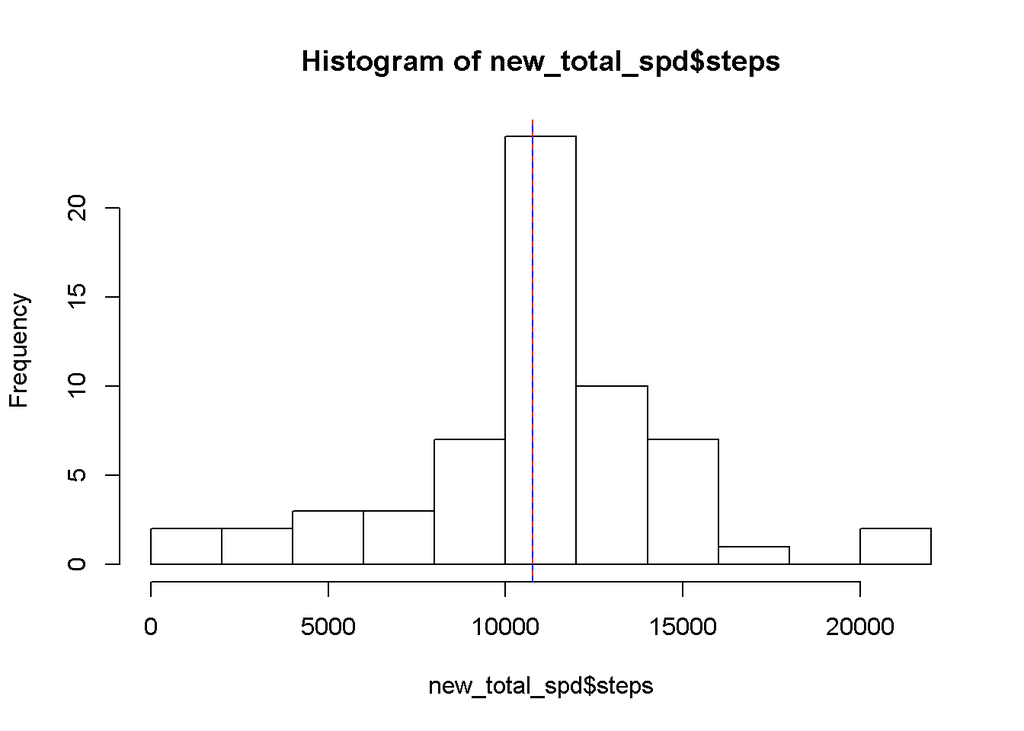

```r
new_total_spd <- group_by(new_activity, date) %>% summarize(steps = sum(steps, na.rm = TRUE)) %>% filter(steps != 0)
new_mean_total_spd <- mean(new_total_spd$steps)
new_median_total_spd <- median(new_total_spd$steps)

hist(new_total_spd$steps, breaks=10)
abline(v=new_mean_total_spd, col = c("red"))
abline(v=new_median_total_spd, col = c("blue"), lty = 2)
```

Do these values differ from the estimates from the first part of the assignment?

```r
mean_total_spd
```

```
## [1] 10766.19
```

```r
new_mean_total_spd
```

```
## [1] 10766.19
```

```r
median_total_spd
```

```
## [1] 10765
```

```r
new_median_total_spd
```

```
## [1] 10766.19
```

What is the impact of imputing missing data on the estimates of the total daily number of steps?

```r
length(index)
```

```
## [1] 2304
```

```r
new_index <- which(is.na(new_activity$steps))
length(new_index)
```

```
## [1] 152
```

## Are there differences in activity patterns between weekdays and weekends?

1. Create a new factor variable in the dataset with two levels - “weekday” and “weekend” indicating whether a given date is a weekday or weekend day.

```r
library(lubridate)
week_activity <- new_activity
week_activity$day <- wday(new_activity$date)
week_activity <- mutate(week_activity, week = ifelse((day == 1 | day == 7), "weekend", "weekday"))
```

2. Make a panel plot containing a time series plot (i.e. type = “l”) of the 5-minute interval (x-axis) and the average number of steps taken, averaged across all weekday days or weekend days (y-axis). See the README file in the GitHub repository to see an example of what this plot should look like using simulated data.

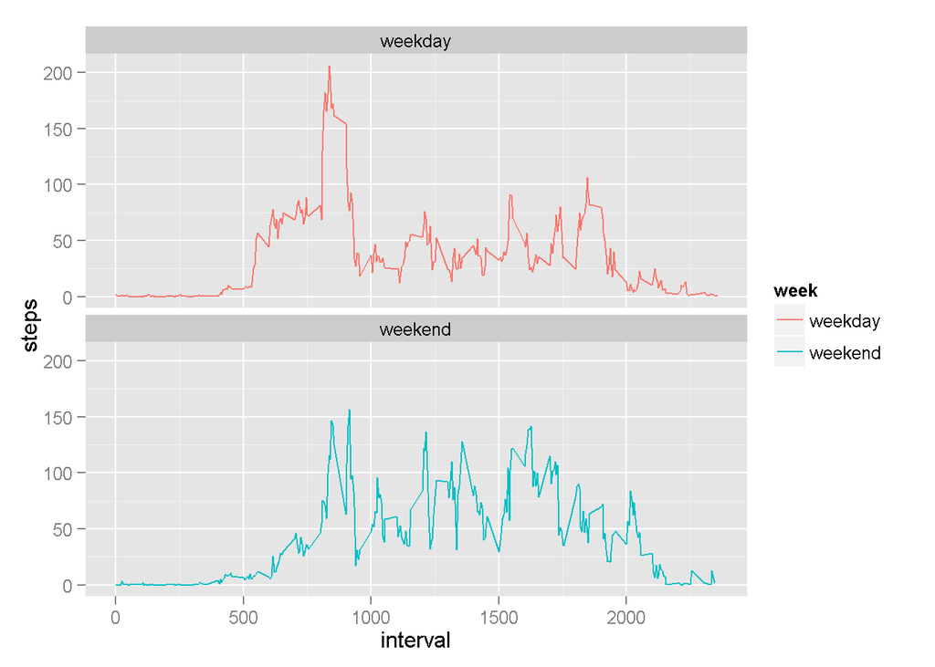

```r
week_spi <- group_by(week_activity, interval, week) %>% summarize(steps = mean(steps, na.rm = TRUE)) %>% filter(steps != 0)
max_week_spi <- filter(week_spi, steps == max(steps))

library(ggplot2)
ggplot(data=week_spi, aes(x=interval, y=steps, group=week)) + geom_line(aes(color=week)) + facet_wrap(~ week, nrow=2)
```